# Projet STA101

## 2. Graphique des variables

### a. Toutes les variables

La fonction get_mfa_var() [factoextra] est utilisée pour extraire les résultats pour les variables. Par défaut, cette fonction renvoie une liste contenant les coordonnées, les cos2 (cosinus carré) et les contribution de toutes les variables:

La figure suivante montre la corrélation entre les variables quantitatives et qualitatives et les axes principaux, ainsi que la contribution des variables aux axes 1 et 2. Les fonctions suivantes [dans le package factoextra] sont utilisées:

.viz_famd_var() pour visualiser les variables quantitatives et qualitatives  
.fviz_contrib() pour visualiser la contribution des variables aux axes principaux

Dans notre FAMD nous n’avons pas de variables supplémentaires. Toutes les variables sont des variables actives.

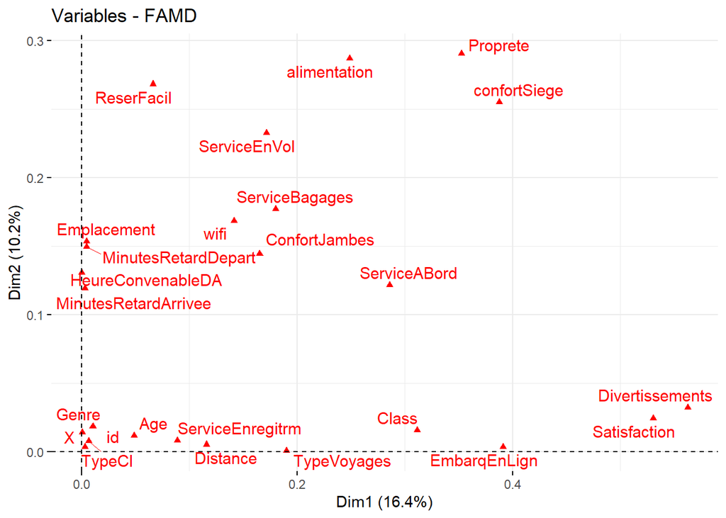

```r
# Graphique des variables
fviz_famd_var (res.famd, repel = TRUE)
```

Nous constatons que toutes les variables sont corrélées positivement à l’axe 1 et 2. Les variables ‘Divertisssement’ et ‘Satisfaction’ sont les variables qui ont le plus contribué à la construction du premier axe. Les variables ‘Propreté’ , ‘alimentation’, ‘confortSiege’, ReservFacil et ‘ServiceEnVol’ sont les variables qui ont le plus contribué à la construction du deuxième axe.

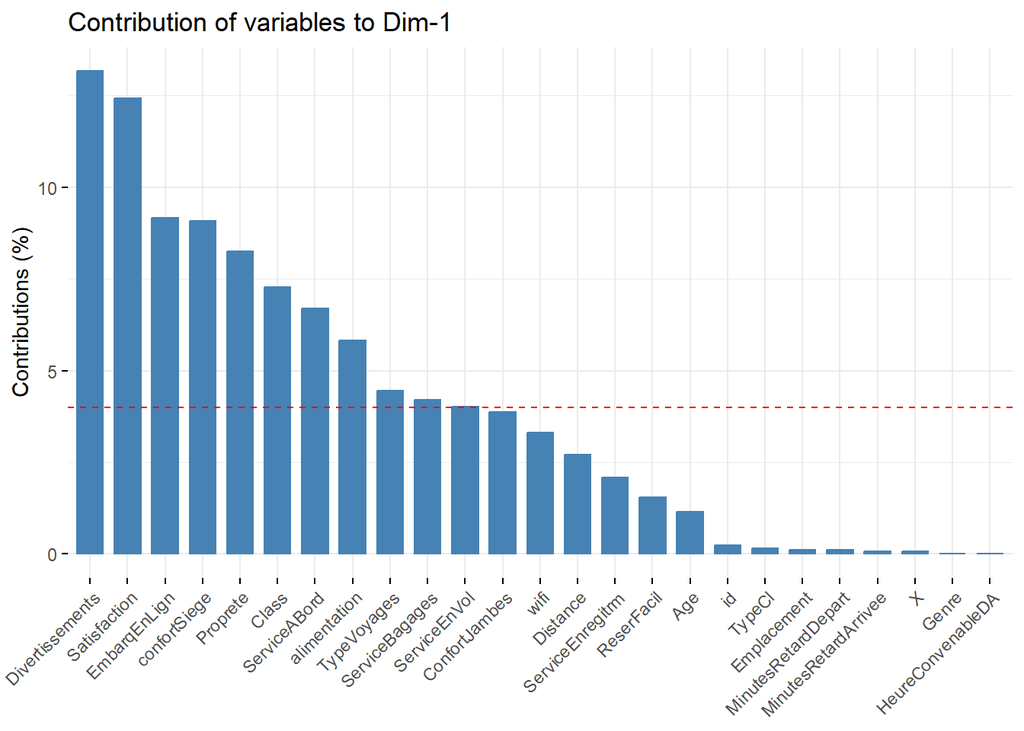

```r
# Contribution à la première dimension
fviz_contrib (res.famd, "var", axes = 1)
```

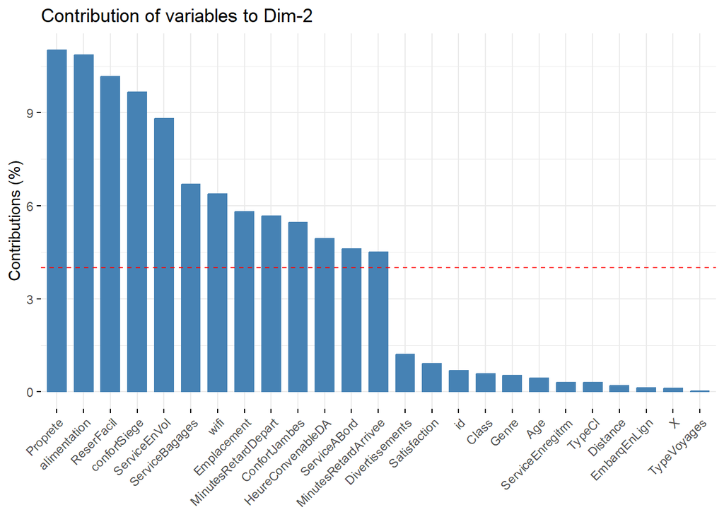

```r
# Contribution à la deuxième dimension
fviz_contrib (res.famd, "var", axes = 2)
```

### b. Variables quantitatives

Pour extraire les résultats pour les variables quantitatives, il faut taper ceci:

```r
quanti.var <- get_famd_var(res.famd, "quanti.var")
quanti.var
```

```
## FAMD results for quantitative variables
##  ===================================================
##   Name       Description
## 1 "$coord"   "Coordinates"
## 2 "$cos2"    "Cos2, quality of representation"
## 3 "$contrib" "Contributions"
```

Dans cette section, nous décrirons comment visualiser les variables quantitatives. De plus, nous allons montrer comment mettre en évidence les variables selon leurs qualités de représentation ou leurs contributions aux dimensions.

En bref, le graphique des variables (cercle de corrélation) montre le lien entre les variables, la qualité de la représentation des variables, ainsi que la corrélation entre les variables et les dimensions.

Le code R ci-dessous présente les variables quantitatives. Nous utilisons “repel = TRUE”, pour éviter le chevauchement de textes.

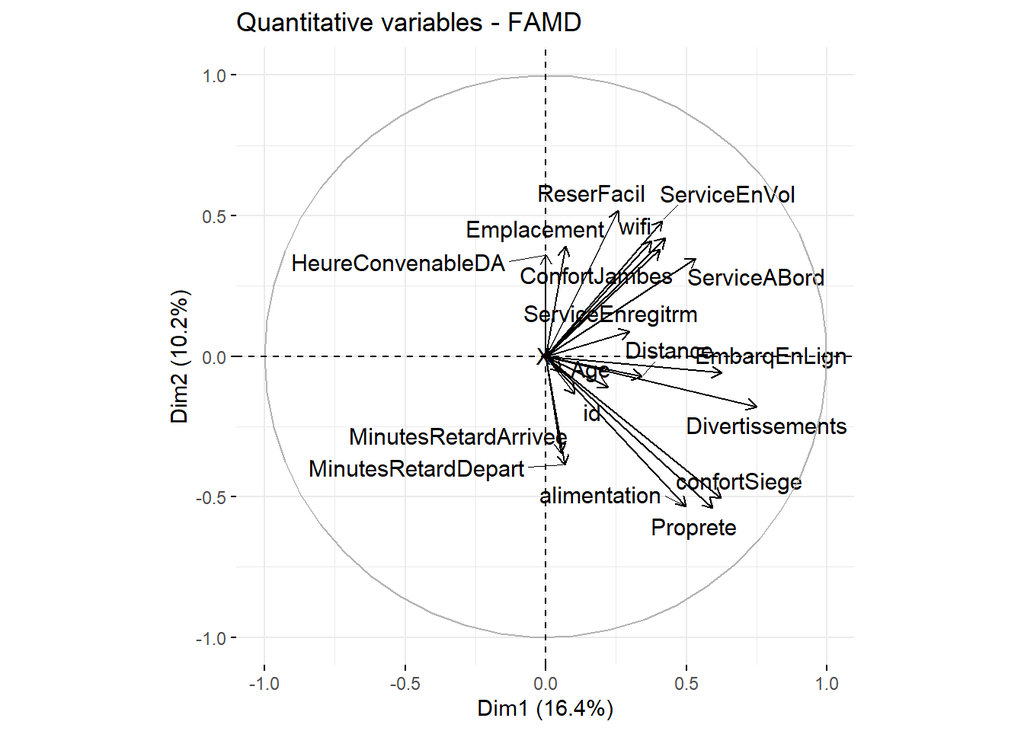

```r
fviz_famd_var(res.famd, "quanti.var", repel = TRUE,col.var = "black")
```

Si ces variable était bien projetée, on aurait dire qu’elles étaient corrélées. Mais comme ce n’est pas le cas, on se basera sur la matice de corrélation.

. Wifi et reserFacil: 70%  
. Proprete et alimentation: 70%  
. Proprete et conforSiege : 69%  
. Proprete et Divertissement : 68%  
. ServiceEnVol et ServiceABord : 59%  
. ServiceEnVol et ServiceBagages : 58%  
. Divertissement et alimentation : 61%  
. ConfortSiege et alimentation: 56%

Les variables quantitatives les plus contributives peuvent être mises en évidence sur le graphique en utilisant l’argument col.var = “contrib”. Cela produit un gradient de couleurs, qui peut être personnalisé à l’aide de l’argument gradient.cols.

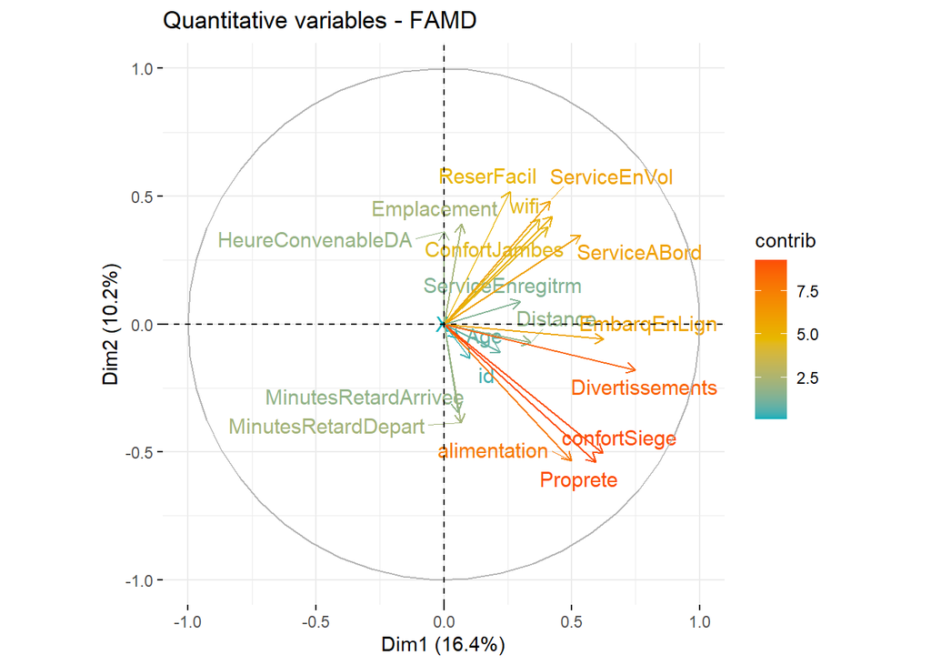

```r
fviz_famd_var(res.famd, "quanti.var", col.var = "contrib",
             gradient.cols = c("#00AFBB", "#E7B800", "#FC4E07"),
             repel = TRUE)
```

Les variables quantitatives peuvent aussi être mis en évidence en utilisant leurs cos2 représentant la qualité de représentation. Si une variable est bien représentée par deux dimensions, la somme des cos2 est proche de 1. Pour certains des éléments, plus de 2 dimensions pourraient être nécessaires pour représenter parfaitement les données.

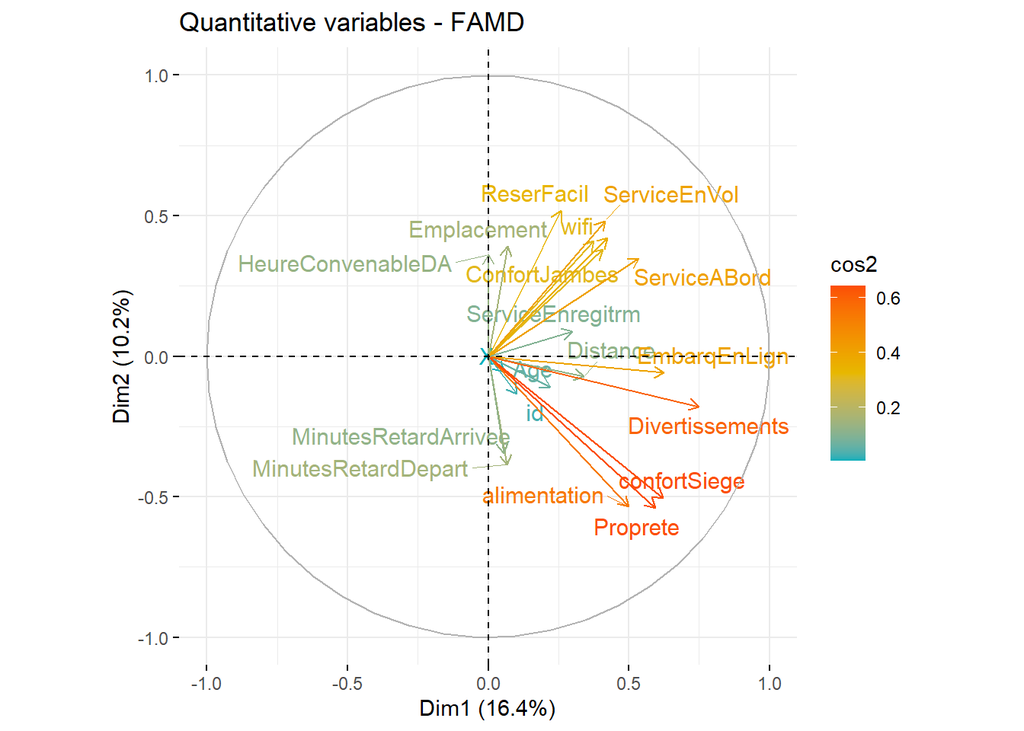

```r
# Couleur par valeurs cos2: qualité sur le plan des facteurs
fviz_famd_var(res.famd, "quanti.var", col.var = "cos2",
             gradient.cols = c("#00AFBB", "#E7B800", "#FC4E07"),
             repel = TRUE)
```

### c. Variables qualitatives

Comme les variables quantitatives, les résultats pour les variables qualitatives peuvent être extraits comme suit:

```r
quali.var <- get_famd_var(res.famd, "quali.var")
quali.var
```

```
## FAMD results for qualitative variable categories
##  ===================================================
##   Name       Description
## 1 "$coord"   "Coordinates"
## 2 "$cos2"    "Cos2, quality of representation"
## 3 "$contrib" "Contributions"
```

Pour visualiser les variables qualitatives, nous tapons ceci:

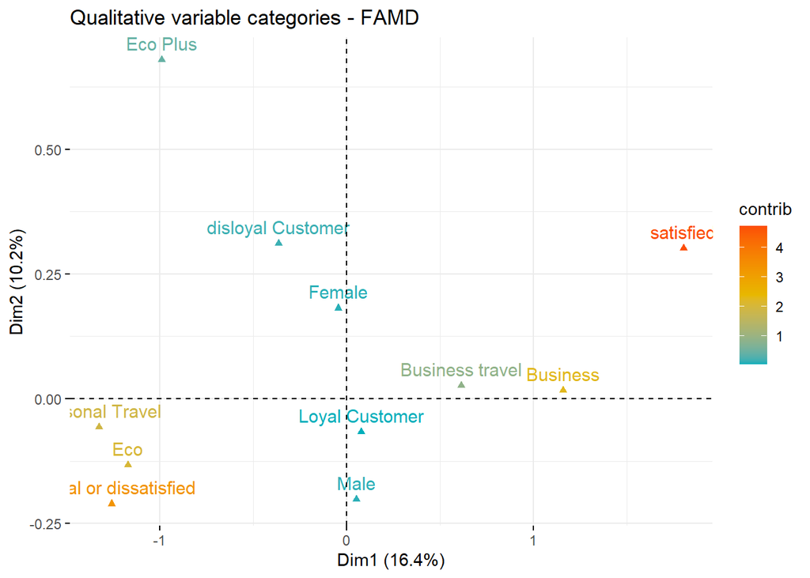

```r
fviz_famd_var(res.famd, "quali.var", col.var = "contrib",
             gradient.cols = c("#00AFBB", "#E7B800", "#FC4E07")
             )
```

Le graphique ci-dessus montre la représentation des modalités des variables catégorielles selon les axes. Nous constatons que les modalités qui ont le plus contribué à la construction du premier axe sont les modalités ‘satisfied’, ‘Business’,’ Personnal travel’, ‘neutral or dissatisfied’ et ‘Eco’. Les modalités qui ont le plus contribué à la construction du deuxième axe sont ‘Eco Plus’ et ‘disloyal Customer’.

Nous remarquons que les clients satisfaits sont à doite, ce sont pluôt des clients qui voyagent en Business classe, qui font des voyages d’affaires, des clients fidèles. Les clients neutrent ou pas satisfaits sont à gauche, ce sont des clients qui voyagent en classe économique ou économique plus, des client non fidélisés, des client qui effectuent des voyages de loisirs.

#### Interprétation :

Le passagers satisfaits sont plutôt des passagers fidélisés qui voyagent en classe d’affaire et pour des raison professionelles.  
Ces clients bénéficient d’une attention particulière du personnel à bord. Le repas est d’une qualité supérieure par rapport à ceux qui servis en “Eco Plus” et “Eco”. Les sièges sont beaucoup plus confortables en business classe que dans les autres classes, permettent une position allongé.Tout ceci contribue à rendre le voyage plus agréable.

Les passagers neutres ou pas satisfaits sont plutôt des passagers qui voyagent en “Eco” et “Eco Plus”.Ce sont des clients qui effectuent des voyages de loisirs. Dans ces deux classes le service à bord est impersonnel, les repas sont servis dans des barquettes, l’espace entre les sièges est très réduit afin d’optimiser la rentabilité de l’avion.

### d. Graphique des individus

Pour obtenir les résultats pour les individus, nous tapons ceci:

```r
ind <- get_famd_ind(res.famd)
ind
```

```
## FAMD results for individuals
##  ===================================================
##   Name       Description
## 1 "$coord"   "Coordinates"
## 2 "$cos2"    "Cos2, quality of representation"
## 3 "$contrib" "Contributions"
```

Pour visualiser les individus, nous utilisons la fonction fviz_famd_ind() [factoextra]. Par défaut, les individus sont colorés en bleu. Cependant, comme des variables, il est également possible de colorer les individus par leurs cos2 et leurs valeurs de contribution:

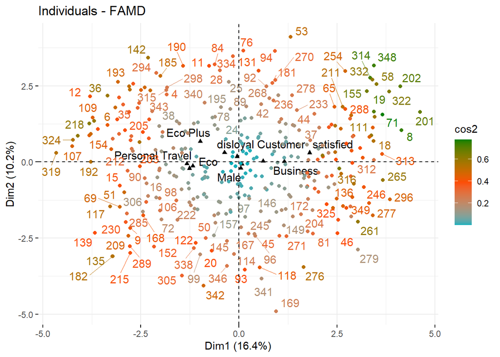

```r
fviz_famd_ind(res.famd, col.ind = "cos2",
             gradient.cols = c("#00AFBB","#FC4E07","#008000"),
             repel = TRUE)
```

Dans le graphique ci-dessus, les catégories des variables qualitatives sont affichées en noir. Si on ne souhaitez pas les afficher sur le graphique,on utilise l’argument invisible = “quali.var”.  
Les modalités sont au centre des individus qui la composent.Les individus ayant des profils similaires sont proches dans le graphique. Les individus les mieux réprésentés sont les individus en en vert à savoir les individus 8, 71, 19, 314 et 348.  
Les individus les moins biens représentés sont les individus en bleus à savoir les individus 24, 157, 176 et 178.

Nous décidons de colorer les individus en utilisant la variable qualitative “satisfaction”. Pour ce faire, l’argument habillage est utilisé dans la fonction fviz_famd_ind().

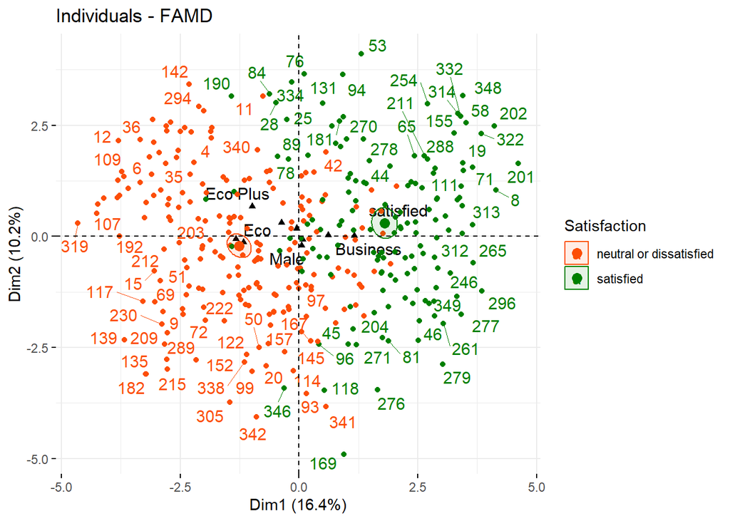

```r
fviz_famd_ind(res.famd,
             habillage = "Satisfaction", # color by groups
             palette = c("#FC4E07","#008000"),
             addEllipses = TRUE, ellipse.type = "confidence",
             repel = TRUE # Avoid text overlapping
             )
```

La figure ci-dessus montre les individus neutres ou insatisfaits en rouge et les individus satisfaits en vert.

# VI. Classification non supervisée

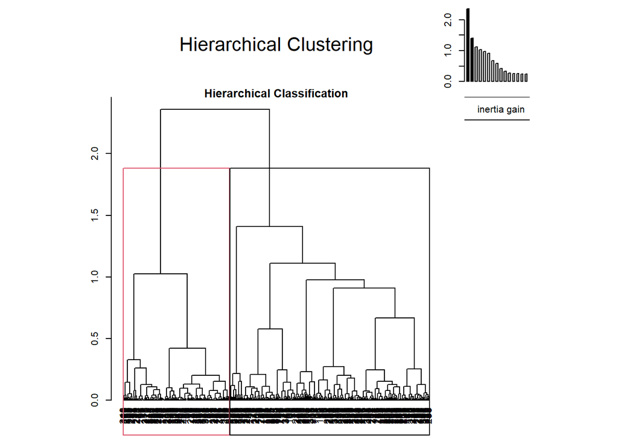

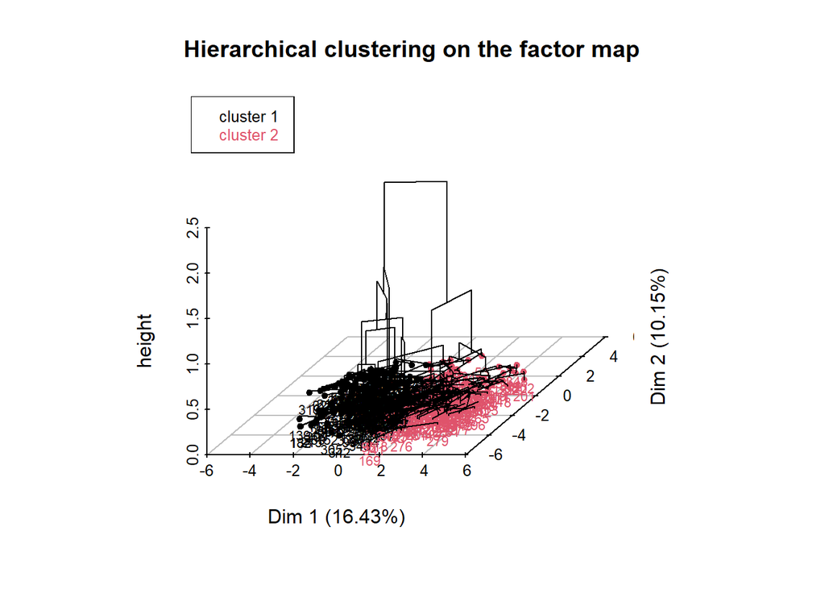

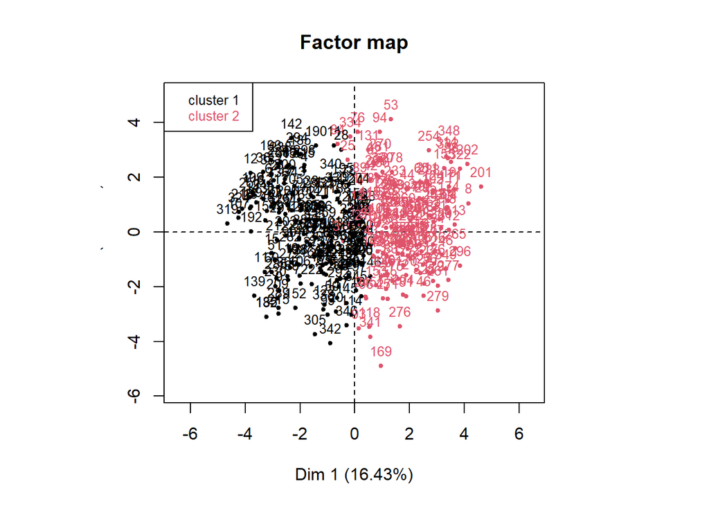

```r
# consol=TRUE fait enchaîner automatiquement un algorithme k-means.
res.hcpc<-HCPC(res.famd,nb.clust=2,consol=TRUE,min=3,max=10,cluster.CA="rows",graph=1)
```

```r
print(res.hcpc)
```

```
## **Results for the Hierarchical Clustering on Principal Components**
##    name
## 1  "$data.clust"
## 2  "$desc.var"
## 3  "$desc.var$quanti.var"
## 4  "$desc.var$quanti"
## 5  "$desc.var$test.chi2"
## 6  "$desc.axes$category"
## 7  "$desc.axes"
## 8  "$desc.axes$quanti.var"
## 9  "$desc.axes$quanti"
## 10 "$desc.ind"
## 11 "$desc.ind$para"
## 12 "$desc.ind$dist"
## 13 "$call"
```

[output cut: 16 more lines]

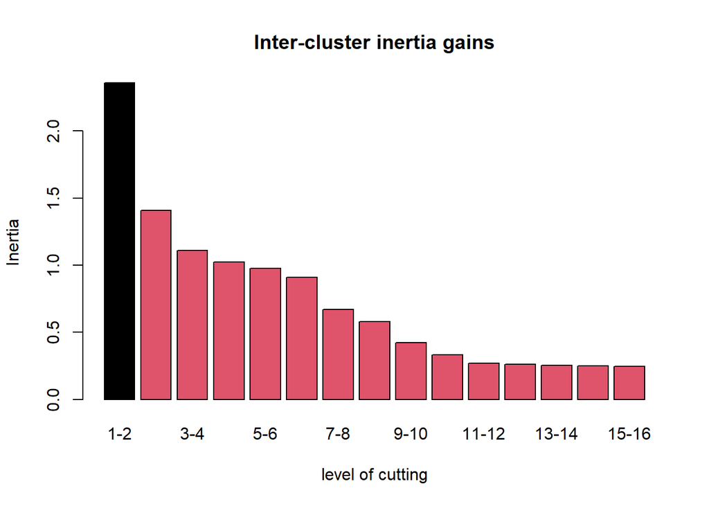

```r
plot(res.hcpc, choice="bar")
```

```r
res.hcpc$desc.var
```

```
##
## Link between the cluster variable and the categorical variables (chi-square test)
## =================================================================================
##                   p.value df
## Satisfaction 6.283201e-44  1
## Class        4.036904e-28  2
## TypeVoyages  4.260536e-20  1
##
## Description of each cluster by the categories
## =============================================
## $`1`
##                                       Cla/Mod   Mod/Cla    Global      p.value
## Satisfaction=neutral or dissatisfied 85.85366 92.146597 58.908046 2.643975e-48
## Class=Eco                            86.00000 67.539267 43.103448 9.591726e-26
## TypeVoyages=Personal Travel          90.90909 52.356021 31.609195 3.445297e-22
## Class=Eco Plus                       76.00000  9.947644  7.183908 2.769286e-02
## TypeVoyages=Business travel          38.23529 47.643979 68.390805 3.445297e-22
## Class=Business                       24.85549 22.513089 49.712644 9.214422e-31
## Satisfaction=satisfied               10.48951  7.853403 41.091954 2.643975e-48
##                                          v.test
## Satisfaction=neutral or dissatisfied  14.604114
## Class=Eco                             10.490109
## TypeVoyages=Personal Travel            9.686378
## Class=Eco Plus                         2.201610
## TypeVoyages=Business travel           -9.686378
## Class=Business                       -11.530929
## Satisfaction=satisfied               -14.604114
##
## $`2`
##                                        Cla/Mod   Mod/Cla    Global      p.value
## Satisfaction=satisfied               89.510490 81.528662 41.091954 2.643975e-48
## Class=Business                       75.144509 82.802548 49.712644 9.214422e-31
## TypeVoyages=Business travel          61.764706 93.630573 68.390805 3.445297e-22
## Class=Eco Plus                       24.000000  3.821656  7.183908 2.769286e-02
## TypeVoyages=Personal Travel           9.090909  6.369427 31.609195 3.445297e-22
## Class=Eco                            14.000000 13.375796 43.103448 9.591726e-26
## Satisfaction=neutral or dissatisfied 14.146341 18.471338 58.908046 2.643975e-48
##                                          v.test
## Satisfaction=satisfied                14.604114
## Class=Business                        11.530929
```

[output cut: 80 more lines]

```
## EmbarqEnLign        1.283476 2.057259e-26
## Divertissements     1.383504 2.915710e-20
## ServiceABord        1.254280 1.742871e-18
## confortSiege        1.418909 5.455936e-15
## ServiceBagages      1.150011 8.237899e-13
## ServiceEnregitrm    1.220162 2.451584e-11
## ServiceEnVol        1.163289 3.592243e-11
## ConfortJambes       1.302900 3.263286e-10
## Proprete            1.344640 3.291256e-10
## wifi                1.269487 5.446244e-09
## Distance          989.081191 2.735906e-08
## alimentation        1.367683 1.049081e-05
## ReserFacil          1.337167 8.519706e-04
## Age                15.251239 3.676198e-03
## HeureConvenableDA   1.567849 1.854953e-02
```

## 1. Profilage

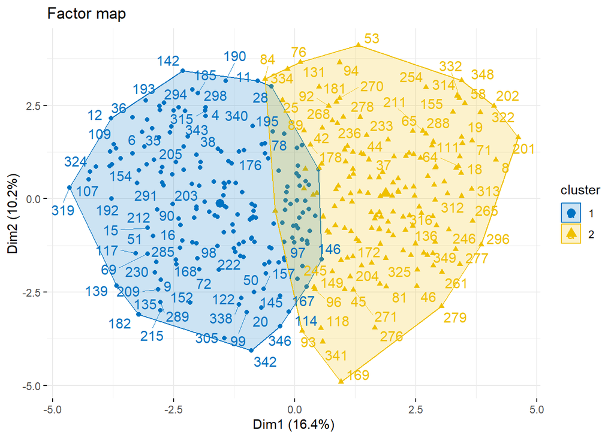

```r
fviz_cluster(res.hcpc,
             repel = TRUE,            # Evite le chevauchement des textes
             show.clust.cent = TRUE, # Montre le centre des clusters
             palette = "jco",         # Palette de couleurs
             ggtheme = theme_minimal(),
             main = "Factor map"
             )
```

## 2. Analyse des variables qualitatives

Les p-valeurs des variables ‘Satisfaction’, ‘Class’ et ‘TypeVoyages’ sont inférieures au seuil 0,05, donc on peut rejeter l’hypothèse nulle.Ces variables ont des liens significatifs avec les classes.

Classe 2:  
Les modalitées ‘satisfied’,‘Business’,‘Business travel’ont des v-tests en valeur absolue significativement différents de 0. Les variables,’Eco plus’,‘Personnal travel’, ‘Eco’, ‘neutral or dissatisfied’ ont aussi en valeur absolue des v-tests significativement différent de 0. Donc il existe donc un lien entre ces modalités et la classe 2.

## 2. Analyse des variables quantitatives

Classe 1:  
Pour la variable ‘HeureConvenableDA’, les individus de la classe 1 prennent des valeurs significativement différents de 0 et suérieur à la moyenne, car la valeur test est supérieure à 2. Les valeurs sont supérieures à la moyenne parce que la valeur test est positive. Les individus de la classe 1 ont donné en moyenne une note de 3,22 sur échelle de 0 à 5, alors que les individus de toutes les classes y compris la classe 1 ont donné une note de 3,04. Cela signifie que les individus de la classe 1 sont à peu près satisfait des heures d’arrivées et de départ convenables.

Tout le reste des variables quantitatives ont des v-test négatifs et significativement différents de O, plus particulièrement les variables ‘EmbarqEnLign’(v_test égal -10,63) auquelle les individus de la classe 1 ont attribué une note de 2,62 ,alors que les individus de toutes les autres classes y compris la classe 1 lui ont donné une note de 3,29, ‘Divertissements’ (v-test égal -9,22), ‘ServiceABord’ (v-test égal -8,77), ‘confortSiege’ (v-test égal -7,82).  
La moyenne d’âge des personnes interrogée pour cette classe et de 36 ans, inférieure à la moyenne d’âge pour toutes les classes(38 ans).  
Les individus de la classe 1 ont parcouru en moyenne une distance de 988km inférieure à la distance moyenne parcourue des deux classes Soit 1256km.

Class 2:  
Toutes les variables quantitatives ont un v-test significativement différent de 0. La variable la plus caractérisante est la variable ‘EmbarqEnLign’ qui a reçu une note moyenne de 4,09 sur une échelle de 0 à 5, alors que tous les individus de ces deux lasses lui ont attribué une note de 3,29. Les individus de cette classe ont globalement donné de bonnes notes; sauf pour la variable ‘HeureConvenableDA’(v-test égal à -2.35) qui a reçu une note moyenne inférieure à la moyenne des deux classes. La moyenne d’âge des personnes interrogées pour cette classe et de 41 ans, supérieure à la moyenne d’âge pour toutes les classes.  
Les individus de la classe 2 ont parcouru en moyenne une distance de 1581km supérieure à la distance moyenne parcourue des deux classes Soit 1256km.

## 4. Interprétation

Les individus de la classe 1 sont neutres ou insatisfaits, en général plus jeunes et les indivudus de la classe 2 sont satisfaits et moins jeunes.En fonction des distances parcourues on peut déduire que les individus de la classe 1 ont effectué des vols courts courriers ou moyens courriers alors que les individus de la classe 2 ont effectué des longs courriers.

```r
# vérifier sur quelles dimensions la projection des clusters est la plus pertiente.
res.hcpc$desc.axes
```

```
##
## Link between the cluster variable and the quantitative variables
## ================================================================
##             Eta2      P-value
## Dim.1 0.67957205 1.609684e-87
## Dim.5 0.04233127 1.107423e-04
## Dim.3 0.02001458 8.218645e-03
##
## Description of each cluster by quantitative variables
## =====================================================
## $`1`
##           v.test Mean in category  Overall mean sd in category Overall sd
## Dim.3   2.635348        0.1965237 -8.986665e-17       1.404503   1.532176
## Dim.5  -3.832616       -0.2552416  9.104058e-17       1.272680   1.368320
## Dim.1 -15.356155       -1.5449657 -2.647946e-17       1.235946   2.067131
##            p.value
## Dim.3 8.405104e-03
## Dim.5 1.267875e-04
## Dim.1 3.221201e-53
##
## $`2`
##          v.test Mean in category  Overall mean sd in category Overall sd
## Dim.1 15.356155        1.8795442 -2.647946e-17       1.084683   2.067131
## Dim.5  3.832616        0.3105168  9.104058e-17       1.415594   1.368320
## Dim.3 -2.635348       -0.2390830 -8.986665e-17       1.643030   1.532176
##            p.value
## Dim.1 3.221201e-53
## Dim.5 1.267875e-04
## Dim.3 8.405104e-03
```

De le résultat ci-dessus, on constate que:

```r
# desc.ind: les individus les plus typiques de chaque groupes
res.hcpc$desc.ind
```

```
## $para
## Cluster: 1
##      241      194      183      134      160
## 2.519684 2.530835 2.760820 2.782457 2.891345
## ------------------------------------------------------------
## Cluster: 2
##      171      197       66      187      255
## 1.378221 1.778127 2.073130 2.272787 2.326671
##
## $dist
## Cluster: 1
##      306      139      283      319      157
## 8.117103 7.980636 7.940979 7.712047 7.652678
## ------------------------------------------------------------
## Cluster: 2
##       279       169       341       179       312
## 10.975940 10.046615  9.295784  7.758240  7.362288
```

# VII. Conclusion

À la suite de notre étude, nous avons constaté que la majorité des passagers satisfaits sont voyagent en classe d’affaires. La plupart des clients qui voyagent en classe économique ne sont pas satisfaits par les prestation proposées. Le sexe des personnes interrogées n’a pas d’influence sur la satisfaction. Les compagnies aériennes doivent concenter leurs efforts sur la qualité des prestations sur les classes économiques et économique pour capter davantage de client.

# Annexe

## Répartistion des tâches

- Ensemble :  
  ** Analyse factorielle des données mixtes  
  ** Classification ascendante hiérarchique  
  ** Conclusion
- Ibrahima :  
  ** Choix du jeu de données  
  ** Analyse bivariée  
  ** Test Mann-Whitney  
  ** Test chi2
- Ayetan:  
  ** Prétraitement des données  
  ** Analyse univariée  
  **Test de Shapiro-wilk